# Penguin Assignment

## QUESTION 01: Data Visualisation for Science Communication

*Create a figure using the Palmer Penguin dataset that is correct but badly communicates the data. **Do not make a boxplot**.*

### a) Provide your figure here:

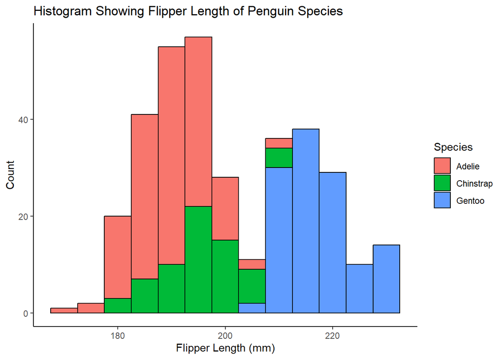

### b) Write about how your design choices mislead the reader about the underlying data (200-300 words).

There are a range of design choices that make it hard to interpret the data correctly in this histogram. Although inferences can be made about general trends in flipper lengths, it would be easy to misinterpret this figure because of its layout. Firstly, the categories are all merged together, so it is hard to separate the trends between the different species. The stacked bars are not appropriate because it is confusing to the reader as it is difficult to interpret what the frequency is for the different species, and it is hard to make comparisons as it does not clearly visualize individual patterns. A side-by-side layout, or transparent bars, would make it easier to interpret the distribution of the data and make easy comparisons. Also, the use of the default colours is a poor design choice because if the reader is red-green colour-blind, they will not be able to distinguish between the Adelie and Chinstrap species, as the stacked bars would appear the same colour. This can be improved by using a colour scheme designed for accessibility (Rocchini *et al.,* 2024). Furthermore, using the ggplot2 “classic” theme removes the gridlines and background shading on the graph, making it harder to interpret given its complexity (Franzblau & Chung, 2012). Another issue is that the bin length is quite large and therefore could be hiding some important underlying trends in the data. Overall, the design choices on this histogram combine to make the visualization of the raw data less effective and mislead the reader about trends in the data.

#### References

Franzblau, L. E., & Chung, K. C. (2012). Graphs, tables, and figures in scientific publications: the good, the bad, and how not to be the latter. *The Journal of hand surgery*, *37*(3), 591-596.

Rocchini, D., Chieffallo, L., Thouverai, E., D’Introno, R., Dagostin, F., Donini, E., … & Nowosad, J. (2024). Under the mantra:‘Make use of colorblind friendly graphs’. *Environmetrics*, *35*(6), e2877.

#### Data:

Gorman KB, Williams TD, Fraser WR (2014). Ecological sexual dimorphism and environmental variability within a community of Antarctic penguins (genus *Pygoscelis*). PLoS ONE 9(3):e90081.

## QUESTION 2: Data Pipeline

*Write a data analysis pipeline in your .rmd RMarkdown file. You should be aiming to write a clear explanation of the steps, the figures visible, as well as clear code.*

*You will be marked on the following:*

#### a) Your code for readability and functionality

#### b) Your figures for communication

#### c) Your text communication of your analysis

*Below is a template you can use.*

### Introduction

The Palmer Penguins dataset contains information on a range of characteristics of three species of penguin. It has information on characteristics such as region, island and clutch completion of these penguins, as well as morphological information such as culmen length and depth, body mass, and flipper length. This dataset therefore has a range of discrete and continuous variables that can be used for analysis of these penguins.

```r
renv::restore()
#Starting off by loading the data
#Loading libraries
library(tidyverse)
library(palmerpenguins)
library(janitor)
library(here)
library(ggplot2)
library(patchwork)
library(ragg)
library(svglite)
library(car)
library(emmeans)

#Here to tell you where we are
#Using the invisible function to hide the output containing my working directory in the html
invisible(here())

#Looking at the dataset
head(penguins_raw)
colnames(penguins_raw)
summary(penguins_raw)
#There are issues with white spaces, brackets, capitalization and clutter
#Writing data to csv using here, this means that the raw data can be loaded again after issues
write.csv(penguins_raw, here("data", "penguins_raw.csv"))
```

However, the “penguins_raw” data contains issues for analysis because of its layout, for example column names have white spaces, irregular capitalization, brackets and there are NAs in the data; this would cause issues in analysis because it is incompatible with the R language. Below is a set of code using a cleaning function to tidy up the data set, getting it ready for analysis. The clean data is written into a csv file so it is safe, and therefore if any analysis goes wrong, it will be stored separately, meaning the original version will be preserved.

```r
#using functions from the functions folder to clean the dataset
source(here("functions", "cleaning.R"))
penguins_clean <- penguins_raw %>%
  clean_column_names() %>% #cleaning the coloumn names
  remove_columns(column_names = "comments") %>% #removing unneeded columns
  shorten_species() %>% #shorten species names
  remove_empty_columns_rows() %>% #remove empty columns and rows
  remove_NA() #remove rows with missing values

#looking to see if this worked
colnames(penguins_clean)
```

```
##  [1] "study_name"        "sample_number"     "species"
##  [4] "region"            "island"            "stage"
##  [7] "individual_id"     "clutch_completion" "date_egg"
## [10] "culmen_length_mm"  "culmen_depth_mm"   "flipper_length_mm"
## [13] "body_mass_g"       "sex"               "delta_15_n_o_oo"
## [16] "delta_13_c_o_oo"
```

```r
#The coloumns have been cleaned successfully
#Writing the clean data to a csv using here so it is protected during analysis
write.csv(penguins_clean, here("data", "penguins_clean.csv"))
```

Once the data has been cleaned, it is ready for exploration of the data. A flexible function was created so the same style of graph could be easily made using different variables, to explore the range of data on these penguins. As seen in the two figures (Figures 1.1 and 1.2) below, the relationship between body size and flipper length, and body size and culmen length are explored between the different species (Adelie, Chinstrap and Gentoo). There are standardized colours used for each of the penguin species. The graphs both suggest patterns between species and these morphological variables, but further analysis is required to look into this.

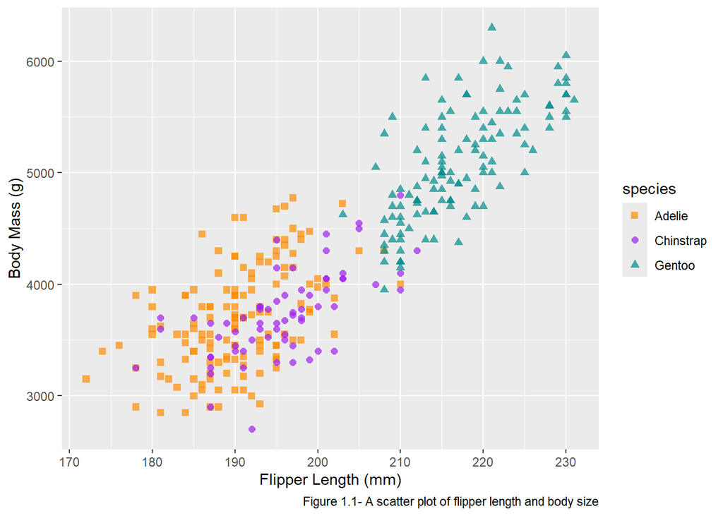

```r
#Looking at flipper length and body mass distributions using scatter graphs
#A function from the plotting.R document is used here
source(here("functions", "plotting.R"))

species_colours <- c("Adelie" = "darkorange",
                     "Chinstrap" = "purple",
                     "Gentoo" = "cyan4")

plot1 <- plot_scatter(penguins_clean,
             flipper_length_mm, body_mass_g,
             "Flipper Length (mm)", "Body Mass (g)",
             species_colours,
             caption = "Figure 1.1- A scatter plot of flipper length and body size")
plot1
```

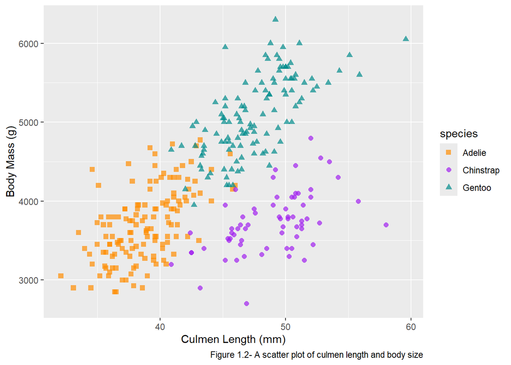

```r
plot2 <- plot_scatter(penguins_clean,
             culmen_length_mm,body_mass_g,
             "Culmen Length (mm)", "Body Mass (g)",
             species_colours,
             caption = "Figure 1.2- A scatter plot of culmen length and body size")
plot2
```

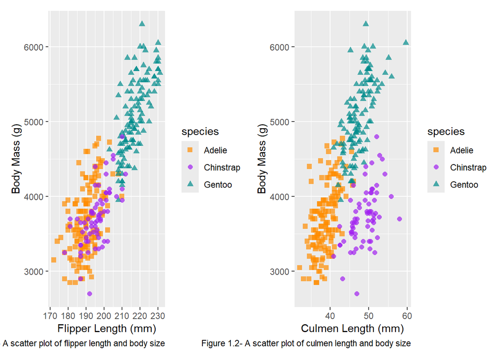

```r
#Using patchwork to make a combined plot of the two graphs
combined_plot <- (plot1 | plot2)
combined_plot
```

The figures are saved into png and svg files so they are stored safely and can be used in a report. The dimensions can also be easily changed for use in different applications, for example for a poster or a PowerPoint. Saving them as a vector (svg) makes them a much higher resolution, leading to higher quality figures.

```r
#saving the figures as pgn files and as vectors for higher resolution
save.plot1.pgn <- plot1
agg_png("figures/penguin_scatter_bodyxflipper.png",
        width = 20, height = 20, units = "cm", res = 300, scaling = 2)
print(save.plot1.pgn)
dev.off()
```

```r
save.plot1.svg <- plot1
inches_conversion = 2.54
svglite("figures/penguin_scatter1_vector.svg",
        width = 20 / inches_conversion,
        height = 20 / inches_conversion,
        scaling = 2)
print(save.plot1.svg)
dev.off()
```

```r
save.plot2.png <- plot2
agg_png("figures/penguin_scatter_bodyxculmen.png",
        width = 20,
        height = 20,
        units = "cm",
        res = 300,
        scaling = 2)
print(save.plot2.png)
dev.off()
```

```r
save.plot2.svg <- plot2
inches_conversion = 2.54
svglite("figures/penguin_scatter2_vector.svg",
        width = 20 / inches_conversion,
        height = 20 / inches_conversion,
        scaling = 2)
print(save.plot1.svg)
dev.off()
```

```r
#This has saved the figures into the folder in the project
```

### Hypothesis

This analysis will focus on the relationship between species and flipper length, accounting for differences in body size, as this is likely to have an impact on flipper length. This can have biological importance because different sized flipper length may be adaptive to the different niches of the penguins. Preregistering hypotheses before conducting an analysis can help increase reproducibility.

The null hypothesis (H0) is that there is no difference in flipper length between different species. The alternative hypothesis (H1) is that there is a significant difference between the three penguin species. It is also expected that body size will also have a significant effect on flipper length, hence it will be accounted for.

### Statistical Methods

```r
#Using an Ancova model to see whether flipper length is different between the different species, with body size as a covariate
ancova_flippers <- aov(flipper_length_mm ~ species + body_mass_g, data = penguins_clean)
summary(ancova_flippers)
```

```
##              Df Sum Sq Mean Sq F value Pr(>F)
## species       2  48679   24340   851.4 <2e-16 ***
## body_mass_g   1   5107    5107   178.7 <2e-16 ***
## Residuals   320   9148      29
## ---
## Signif. codes:  0 '***' 0.001 '**' 0.01 '*' 0.05 '.' 0.1 ' ' 1
```

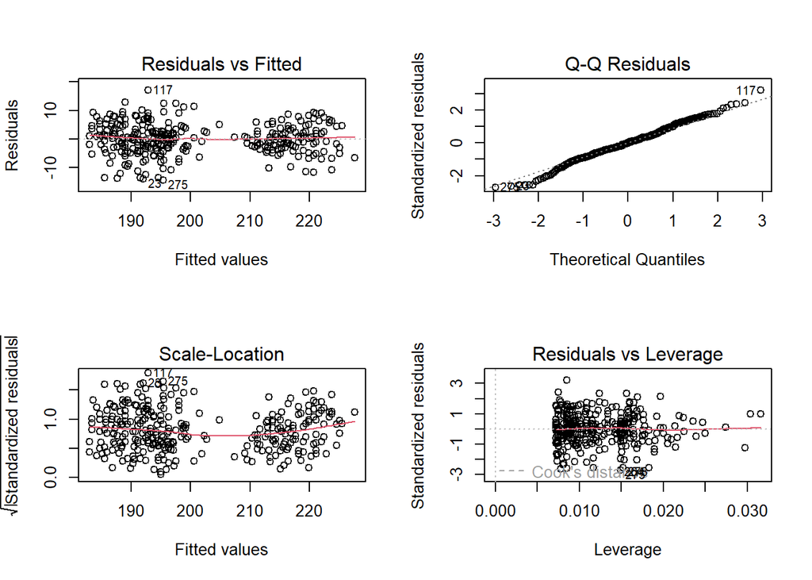

```r
#Checking assumptions of the ancova (linearity, normality, homogeneity of variance)
par(mfrow = c(2, 2))#making it into a multipanel figure
plot(ancova_flippers)
```

```r
#slight deviation from normality in QQ plot
penguins_clean$species <- as.factor(penguins_clean$species)#making species into factors so that the levene test doesn't come up with a warning
leveneTest(flipper_length_mm ~ species, data = penguins_clean)
```

```
## Levene's Test for Homogeneity of Variance (center = median)
##        Df F value Pr(>F)
## group   2  0.4481 0.6392
##       321
```

```r
#P value of 0.6392 means there is not a significant violation of homoscedasticity
#None of the assumptions appear to be severely violated, ANCOVA is robust to a certain level of violations

#pos-hoc analysis using the Tukey-Kramer test
#this is a good test for this data because it adjusts for unequal sample sizes
#using the estimated mariginal means package because the TukeyHSD function does not work with a covariate
emmeans(ancova_flippers, pairwise ~ species, adjust = "tukey")
```

```
## $emmeans
##  species   emmean    SE  df lower.CL upper.CL
##  Adelie       195 0.561 320      194      196
##  Chinstrap    200 0.724 320      198      201
##  Gentoo       210 0.750 320      208      211
##
## Confidence level used: 0.95
##
## $contrasts
##  contrast           estimate    SE  df t.ratio p.value
##  Adelie - Chinstrap    -5.11 0.795 320  -6.429  <.0001
##  Adelie - Gentoo      -14.90 1.120 320 -13.329  <.0001
##  Chinstrap - Gentoo    -9.79 1.200 320  -8.157  <.0001
##
## P value adjustment: tukey method for comparing a family of 3 estimates
```

```r
#significant difference between all of the pairs
```

### Results & Discussion

Table of Results from Post-Hoc Analysis

| Pairwise comparisons | Estimated difference in means | Standard error | Degrees of Freedom | t statistic | p value |
| --- | --- | --- | --- | --- | --- |
| Adelie and Chinstrap | -5.11 | 0.795 | 320 | -6.429 | <.0001 |
| Adelie and Gentoo | -14.90 | 1.120 | 320 | -13.329 | <.0001 |
| Chinstrap and Gentoo | -9.79 | 1.200 | 320 | -8.157 | <.0001 |

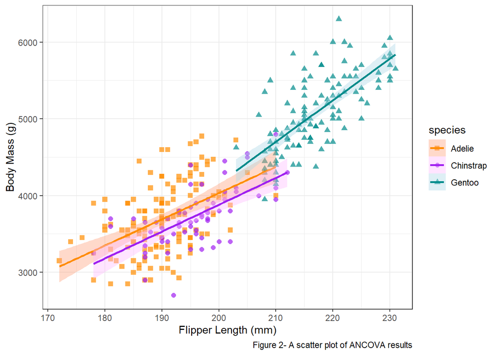

```r
#using the a function from the plotting.R document again
 source(here("functions", "plotting.R"))

#setting colours for the confidence intervals on the regression lines
CI_colours <- c("Adelie" = "lightsalmon",
                "Chinstrap" = "plum1",
                "Gentoo" = "lightblue")

#plotting the results of the ancova onto the scatter graph to show the regression lines for better interpretation of the results
#using the function from plotting.R
ancova.plot <- plot_ancova_results(ancova_flippers,
             flipper_length_mm, body_mass_g,
             "Flipper Length (mm)", "Body Mass (g)",
             species_colours,
             caption = "Figure 2- A scatter plot of ANCOVA results")
ancova.plot
```

```r
#saving the plot as a png and then as a svg using the functions in the plotting.R document
save_plot_png(ancova.plot,
              here("figures", "ancova.plot.png"),
              size = 20, res = 300, scaling = 2)
```

```r
save_plot_svg(ancova.plot,
              here("figures", "ancova.plot.svg"),
              size = 20, scaling = 2)
```

```r
#creating a renv snapshot for reproducibility
#renv::snapshot()
```

### Conclusion

To conclude, this analysis demonstrated that flipper length is significantly affected by species and body mass, and it was significantly different between all three species. Gentoo penguins have the largest flipper lengths, followed by Chinstrap then Adelie. This may have biological significance in functional aspects of flipper length, for example adapting to their niche by affecting swimming speed. Further analysis could look into the relationship between flipper length and ecological niche in these penguins. Techniques were used to ensure that the results of these analyses were reproducible.

## QUESTION 3: Open Science

### a) GitHub

*Upload your RProject you created for **Question 2** and any files and subfolders used to GitHub. Do not include any identifiers such as your name. Make sure your GitHub repo is public.*

*GitHub link:* https://github.com/giraffe145/PenguinAssignment.git

*You will be marked on your repo organisation and readability.*

### b) Share your repo with a partner, download, and try to run their data pipeline.

*Partner’s GitHub link:*

I reviewed this person’s code: https://github.com/biologystudentpenguins/reproducible_figures_assessment.git

This person reviewed my code: https://github.com/Dinosaur88/Reproducible_research_assignment.git

*You **must** provide this so I can verify there is no plagiarism between you and your partner.*

### c) Reflect on your experience running their code. (300-500 words)

- *What elements of your partner’s code helped you to understand their data pipeline?*
- *Did it run? Did you need to fix anything?*
- *What suggestions would you make for improving their code to make it more understandable or reproducible, and why?*
- *If you needed to alter your partner’s figure using their code, do you think that would be easy or difficult, and why?*

#### Answer:

  Almost every line of code in this person’s pipeline is given an explanation, which is helpful because it sets out what the goal of each step of the code is. It is also useful that the code is clearly named, so you can tell what it is (for example “penguins_data_clean” is easy to understand that it is the clean penguin data). The text outside of the data pipeline is also detailed and valuable to understand the logic behind all of the code that is being written. It followed a very rational structure, and I therefore felt like I understood what was happening in every step of the pipeline. Splitting up the code into chunks with R Markdown meant that each part could be run individually, and therefore each section was understandable and cohesive, with explanation in between. The use of functions in a different document kept number of lines of code down to a minimum, making it easier to see what is being done, and the functions are cleanly presented in a folder. A suggestion to make this more understandable is to state within the pipeline when a function is being used and direct the reader to the document containing that function, so it is easier to find (for example when “plot_exploratory_figure” is used, say that it is in the plotting.R document).

  I had to download some packages in order to load the libraries, but because they were all in one place, this was easy to do at the beginning, before running any code. The pipeline ran really well, except for one minor error in line 319 in which “flipper_mass_data” should have been “flipper_mass_data_clean”, and this meant that R didn’t recognise it and didn’t plot the results figure successfully. This, however, was easy to correct because everything had been organised so logically, meaning it was easy to find the intended name. If I needed to alter my partner’s figure, I think that it would be easy because every line of the function is labelled and therefore it is easy to understand what is going on, and therefore you can know exactly what you are altering. An improvement that I would make to the function is perhaps to make it more general, so that you could use same function to produce different figures depending on how you code it. For example, for the exploratory figure, the x and y values are set as flipper length and body mass in the function, whereas this could be generalised so different variables could be used in the pipeline when using this function.

### d) Reflect on your own code based on your experience with your partner’s code and their review of yours. (300-500 words)

- *What improvements did they suggest, and do you agree?*
- *What did you learn about writing code for other people?*

#### Answer

  One of the improvements that were suggested for my code was removing redundant code, this has taught me to always triple-check the output of my code because I did not intend to keep in multiple copies of some of the figures (as they were only there at first to check the code worked, then I should have taken them out). Another suggestion was to include titles on the figures; I didn’t do this originally because many journal figures do not have titles, but perhaps the figures would be easier to understand with a title. Also, it was unexpected that my partner had to manually download packages because I predicted this would be done by renv, but I have learned that in the future I need to try it out on other people’s laptops so that I can ensure that I have configured renv correctly, as this is really important for reproducibility because a reader would be able to use the exact same packages as me in this process.

  It was really interesting to work through someone else’s code because it brings to light aspects of your own code that you wouldn’t otherwise notice. For example, in the future, I will label the individual steps of a function in more detail because I found this really useful for understanding another person’s code and their logic behind each step. I also think that my code could be improved through making it more concise and making more use of functions to avoid clutter in the final pipeline. Through this exercise, I have realised the importance of understanding in reproducibility, because in order to recreate something, you must first understand it. For example, if I were to make alterations to their graphs, I need to understand every step of their code in order to do this. Furthermore, looking at their code allowed me to make my own inferences about the data that they were exploring, because it provides more information than just their explanations, and you get to see the logic behind the conclusions that have been made. I have also realised how important it is to name things in a way that makes sense to others, so that they can interpret your code, and it is useful break the code down into sections that can be followed logically. It is also really important to be consistent and document each aspect of your code to consider a user without prior knowledge. Finally, I have learned about the importance of sharing code with other people because it helps amplify learning and understanding for both the person reading the code and the person who wrote it.